# Diagnostic Report for OM #: 170

North Atlantic Swordfish MSE

Adrian Hordyk adrian@bluematterscience.com

September 07, 2022

# 1 Operating Model Scenario

Table 1. The uncertainty grid is a full factorial design with the following 7 factors, resulting in 216 OMs. The parameters used to condition this OM are indicated with bold text in blue boxes.

**OM Name**: MOM_170

[output not shown]

# 2 Fleet and Data Summary

Table 2. Summary table of the fishing fleets and indices of abundances used to condition this operating model.

| Name | Code |
| --- | --- |
| EU-Spain longline (LL) | SPN_1 |
| USA LL | US_2 |
| Canada LL | CAN_3 |
| Japan LL - Early | JPN_ERLY_4 |
| Japan LL - Late | JPN_LATE_5 |
| EU-Portugal LL | PORT_6 |
| Chinese-Taipai LL - Early | CHT_EARLY_7 |
| Chinese-Taipai LL - Late | CHT_LATE_8 |
| Morocco LL | MOR_9 |
| Canada/USA Harpoon | HRPN_10 |
| Other - LL by the other CPCs, and all other gears except HP | OTH_11 |
| USA Survey | US_Survey_12 |
| EU-Portugal Survey | PORT_Survey_13 |
| Age-1 Survey | Age-1 |
| Age-2 Survey | Age-2 |
| Age-3 Survey | Age-3 |
| Age-4 Survey | Age-4 |
| Age-5+ Survey | Age-5+ |

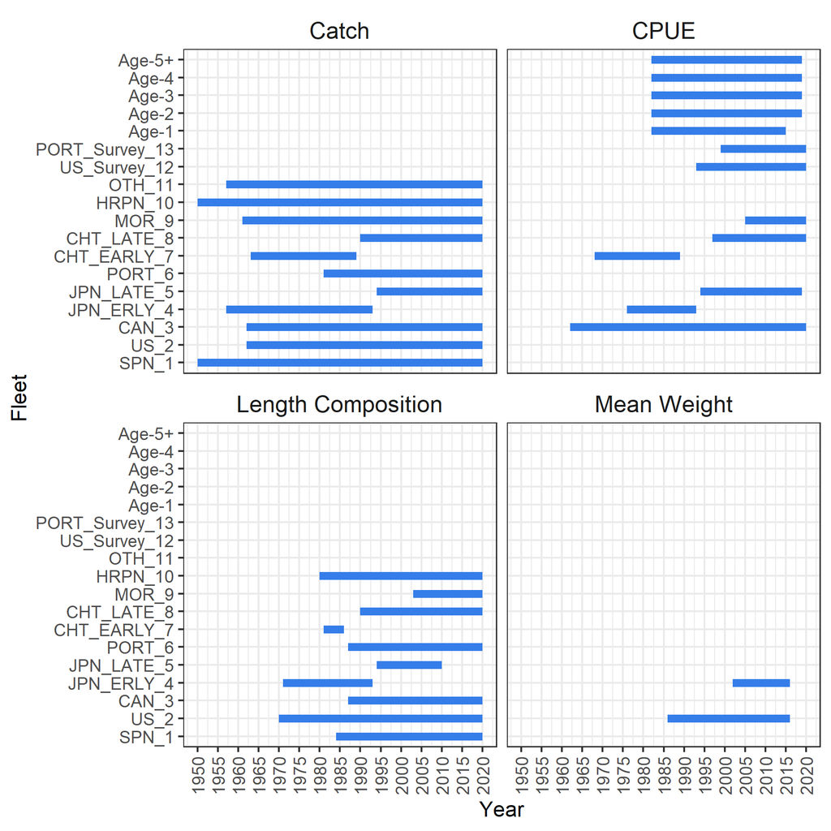

Figure 1. Summary of the data used to condition this operating model.

# 3 Objective Function Values

## 3.1 Overall

Table 3. The total and component overall likelihood values.

| TOTAL | 2569.1700000 |
| --- | --- |
| Catch | 0.0000128 |
| Equil_catch | 0.0000000 |
| Survey | -12.3081000 |
| Discard | 0.0000000 |
| Mean_body_wt | 123.7040000 |
| Length_comp | 2487.0500000 |
| Recruitment | -29.9253000 |
| InitEQ_Regime | 0.0000000 |
| Forecast_Recruitment | 0.0000000 |
| Parm_priors | 0.5832080 |
| Parm_softbounds | 0.0092043 |
| Parm_devs | 0.0000000 |
| F_Ballpark | 0.0543936 |
| F_Ballpark.info_only._2017_estF_tgtF | 0.1438090 |
| Crash_Pen | 0.0000000 |

## 3.2 By Fleet

Table 4. The total and component likelihood values for each fleet.

| Label | Catch_like | Surv_like | Surv_N_use | Disc_like | Disc_N_use | mnwt_like | mnwt_N_use | Length_like | Length_N_use |
| --- | --- | --- | --- | --- | --- | --- | --- | --- | --- |
| ALL | 1.27862e-05 | -1.23081e+01 | NA | 0.00000e+00 | NA | 1.23704e+02 | NA | 2.48705e+03 | NA |
| SPN_1 | 1.59408e-06 | -3.56184e+01 | 3.40000e+01 | 2.79585e+12 | 2.80000e+01 | 0.00000e+00 | 0.00000e+00 | 1.02240e+02 | 3.70000e+01 |
| US_2 | 1.45996e-06 | 0.00000e+00 | 0.00000e+00 | 7.02468e+02 | 2.80000e+01 | 7.84726e+01 | 3.10000e+01 | 1.87860e+03 | 7.60000e+01 |
| CAN_3 | 1.31268e-06 | -2.44604e+01 | 5.10000e+01 | 3.49046e+08 | 2.80000e+01 | 0.00000e+00 | 0.00000e+00 | 7.45784e+01 | 3.40000e+01 |
| JPN_ERLY_4 | 2.32309e-07 | -1.78676e+01 | 1.80000e+01 | 0.00000e+00 | 0.00000e+00 | 4.52319e+01 | 1.50000e+01 | 4.56690e+01 | 2.10000e+01 |
| JPN_LATE_5 | 1.12770e-06 | -1.86324e+01 | 2.00000e+01 | 5.21300e+08 | 2.80000e+01 | 0.00000e+00 | 0.00000e+00 | 5.49432e+01 | 1.60000e+01 |
| PORT_6 | 1.59876e-06 | 0.00000e+00 | 0.00000e+00 | 1.63000e+11 | 2.80000e+01 | 0.00000e+00 | 0.00000e+00 | 3.67715e+01 | 2.80000e+01 |
| CHT_EARLY_7 | 9.59497e-08 | 7.23867e+00 | 2.20000e+01 | 0.00000e+00 | 0.00000e+00 | 0.00000e+00 | 0.00000e+00 | 9.66620e+01 | 6.00000e+00 |
| CHT_LATE_8 | 1.23818e-06 | -5.38459e+00 | 2.40000e+01 | 1.04895e+06 | 1.70000e+01 | 0.00000e+00 | 0.00000e+00 | 6.16765e+01 | 2.90000e+01 |
| MOR_9 | 1.52553e-06 | -5.05719e+00 | 1.60000e+01 | 0.00000e+00 | 0.00000e+00 | 0.00000e+00 | 0.00000e+00 | 2.74144e+01 | 1.40000e+01 |
| HRPN_10 | 1.14108e-06 | 0.00000e+00 | 0.00000e+00 | 0.00000e+00 | 0.00000e+00 | 0.00000e+00 | 0.00000e+00 | 1.08500e+02 | 3.90000e+01 |
| OTH_11 | 1.45997e-06 | 0.00000e+00 | 0.00000e+00 | 4.43778e+11 | 2.80000e+01 | 0.00000e+00 | 0.00000e+00 | 0.00000e+00 | 0.00000e+00 |
| US_Survey_12 | 0.0000 | -34.8684 | 28.0000 | 0.0000 | 0.0000 | 0.0000 | 0.0000 | 0.0000 | 0.0000 |
| PORT_Survey_13 | 0.0000 | -14.2453 | 22.0000 | 0.0000 | 0.0000 | 0.0000 | 0.0000 | 0.0000 | 0.0000 |
| Age-1 | 0.0000 | -12.5946 | 34.0000 | 0.0000 | 0.0000 | 0.0000 | 0.0000 | 0.0000 | 0.0000 |
| Age-2 | 0.000 | -27.721 | 38.000 | 0.000 | 0.000 | 0.000 | 0.000 | 0.000 | 0.000 |
| Age-3 | 0.0000 | -31.5609 | 38.0000 | 0.0000 | 0.0000 | 0.0000 | 0.0000 | 0.0000 | 0.0000 |
| Age-4 | 0.0000 | -24.9167 | 38.0000 | 0.0000 | 0.0000 | 0.0000 | 0.0000 | 0.0000 | 0.0000 |
| Age-5+ | 0.0000 | -36.0202 | 38.0000 | 0.0000 | 0.0000 | 0.0000 | 0.0000 | 0.0000 | 0.0000 |
| Combined_CPUE | 0.000000 | 0.136171 | 49.000000 | 0.000000 | 0.000000 | 0.000000 | 0.000000 | 0.000000 | 0.000000 |

# 4 Fits to CPUE Indices

## 4.1 Time-Series and Deviations

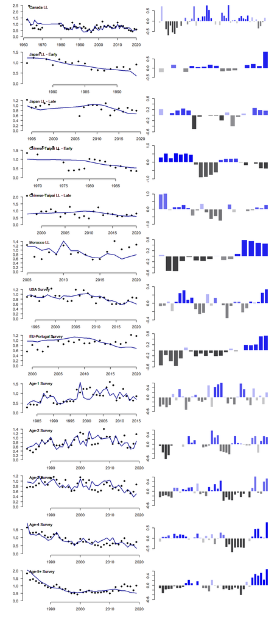

Figure 2. Operating model fits to the indices. Each row corresponds with an index. The left-hand panels show the observed (black dots) and model predicted (blue line) index. The right-hand panels show the log deviations (the observation model is log-normal). Runs of positive residuals are coloured blue, with darker colours indicating longer runs. Run in negative residuals are colored in grey.

## 4.2 Statistical Properties

Table 5. The statistical properties of the model fits to the 13 indices.

| Index # | Fleet | Standard Deviation | Correlation | Auto-Correlation | Root Mean Squared Error | Mean Runs |
| --- | --- | --- | --- | --- | --- | --- |
| 3 | Canada LL | 0.32 | 0.48 | 0.35 | 0.93 | 4.41 |
| 4 | Japan LL - Early | 0.25 | 0.71 | 0.16 | 0.8 | 3.78 |
| 5 | Japan LL - Late | 0.2 | 0.31 | 0.11 | 1.03 | 3.5 |
| 7 | Chinese-Taipai LL - Early | 0.47 | 0.59 | 0.75 | 0.84 | 5.73 |
| 8 | Chinese-Taipai LL - Late | 0.42 | -0.02 | 0.42 | 1.04 | 2.67 |
| 9 | Morocco LL | 0.35 | 0.18 | 0.71 | 1.17 | 5 |
| 12 | USA Survey | 0.18 | 0.6 | 0.33 | 0.8 | 3.14 |
| 13 | EU-Portugal Survey | 0.29 | -0.24 | 0.62 | 1.45 | 5.45 |
| 14 | Age-1 Survey | 0.33 | 0.53 | 0.15 | 0.87 | 2.47 |
| 15 | Age-2 Survey | 0.27 | 0.54 | 0.45 | 0.88 | 3.47 |

[output cut: 3 more lines]

# 5 Fits to Catch Data

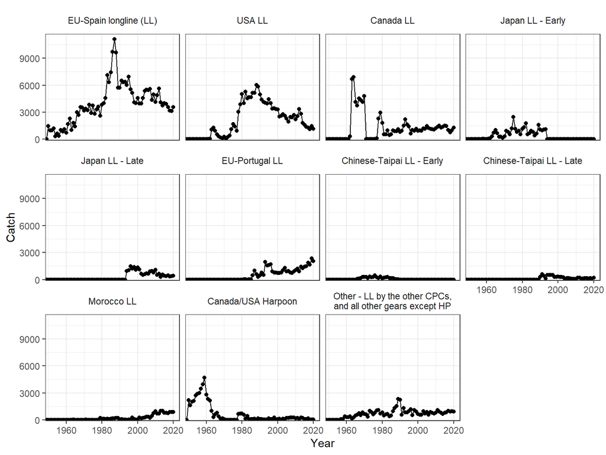

Figure 3. Fits to the catch data for the11 fleets. All panels are shown with the same scale y-axis to indicate the magnitude of catches between fleets.

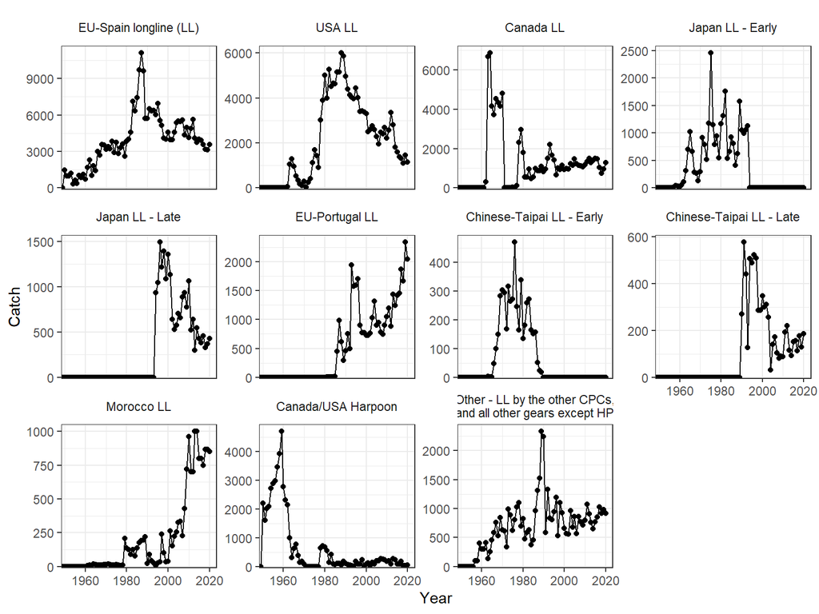

Figure 4. Fits to the catch data for the 11 fleets with each y-axis is scaled separately.

# 6 Fits to Length Composition

## 6.1 Observed and Predicted by Fleet and Year

### 6.1.1 EU-Spain longline (LL)

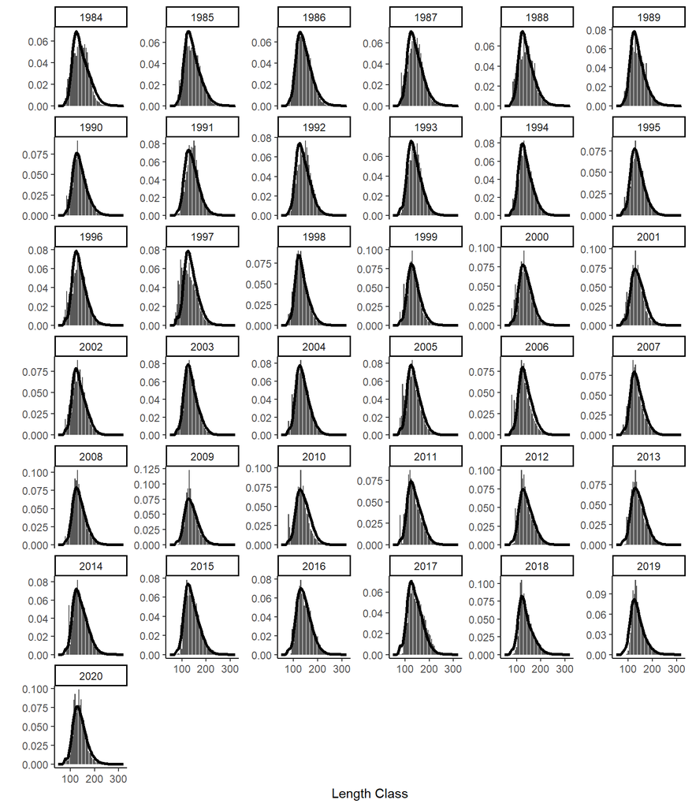

Figure 5. Observed and predicted length composition for EU-Spain longline (LL).

### 6.1.2 USA LL

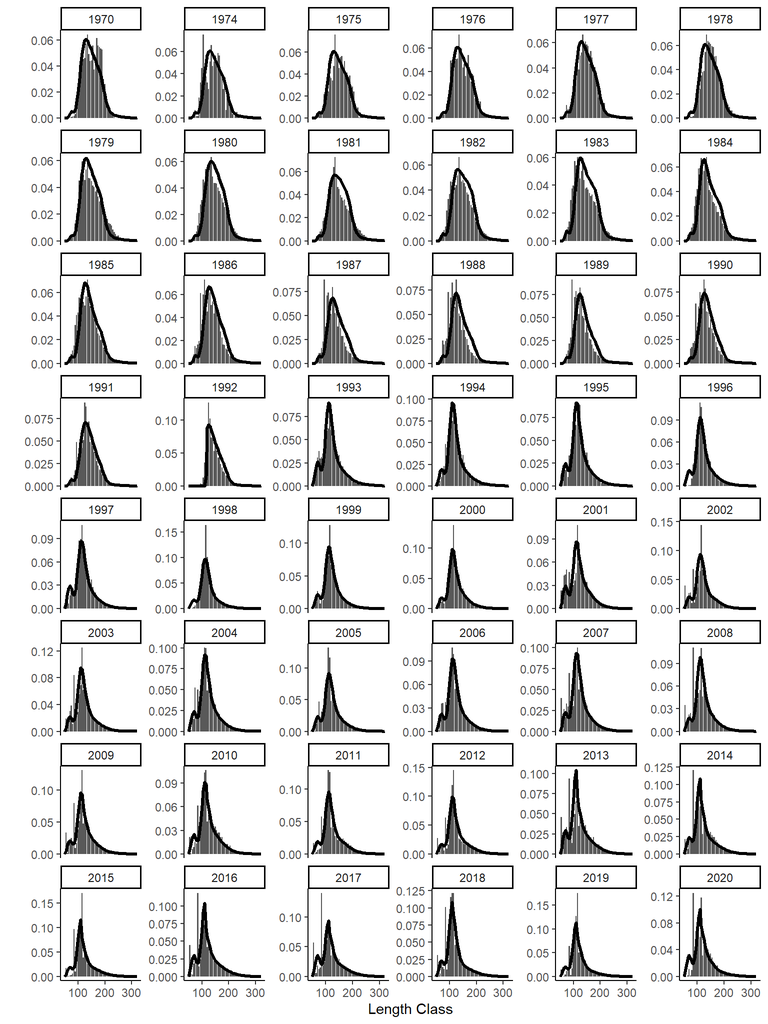

Figure 6. Observed and predicted length composition for USA LL.

### 6.1.3 Canada LL

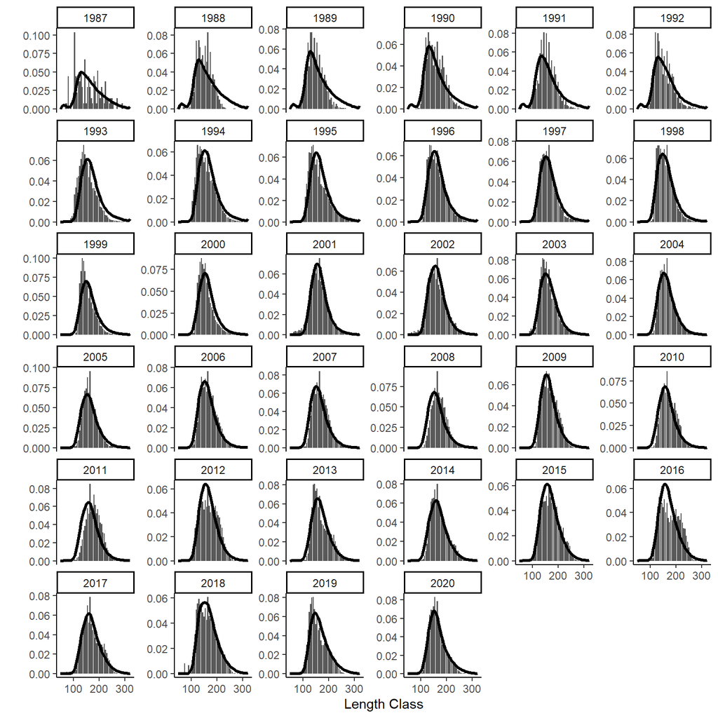

Figure 7. Observed and predicted length composition for Canada LL.

### 6.1.4 Japan LL - Early

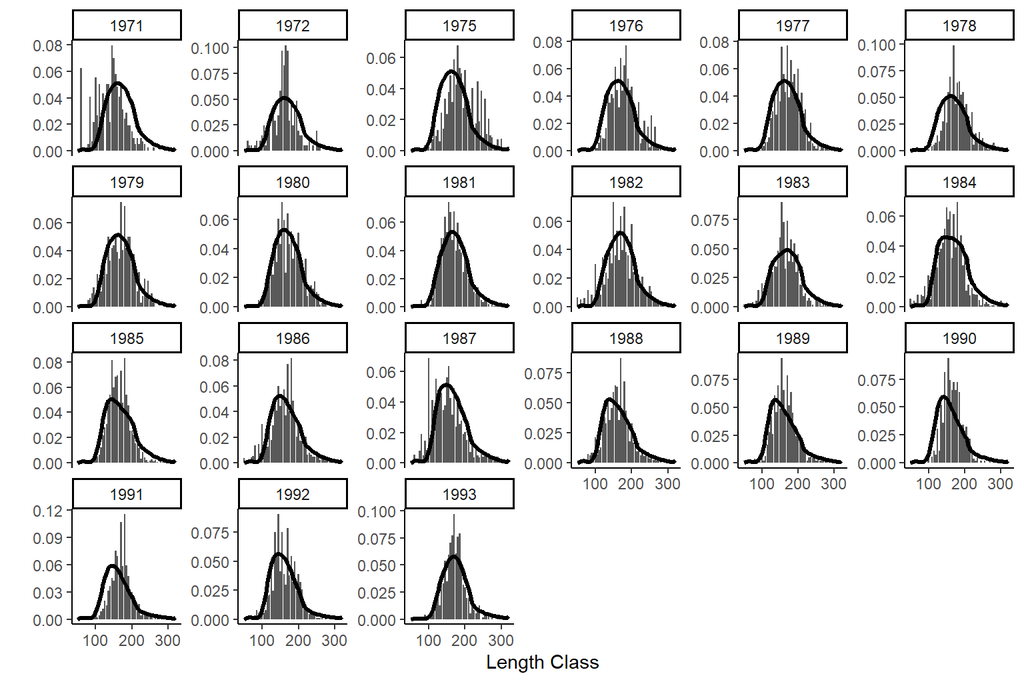

Figure 8. Observed and predicted length composition for Japan LL - Early.

### 6.1.5 Japan LL - Late

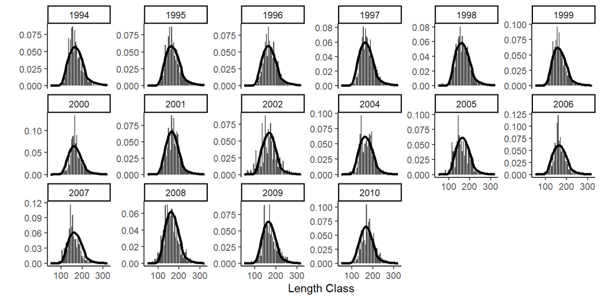

Figure 9. Observed and predicted length composition for Japan LL - Late.

### 6.1.6 EU-Portugal LL

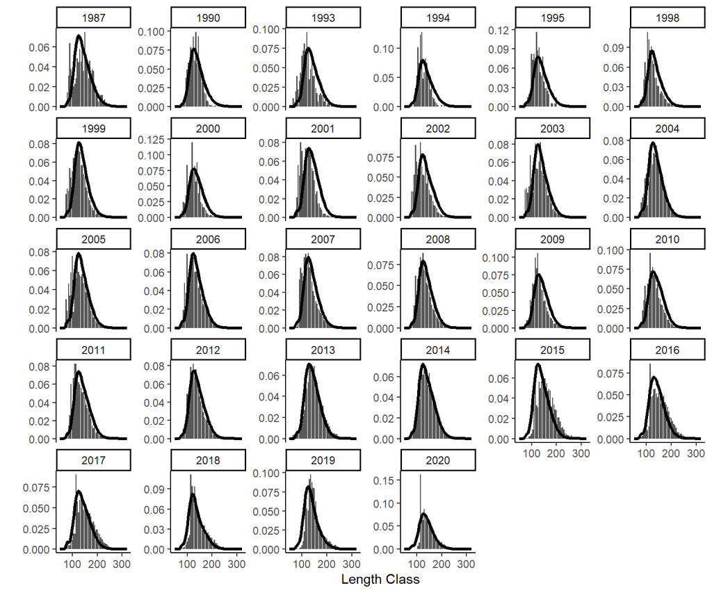

Figure 10. Observed and predicted length composition for EU-Portugal LL.

### 6.1.7 Chinese-Taipai LL - Early

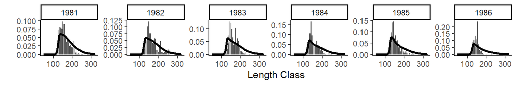

Figure 11. Observed and predicted length composition for Chinese-Taipai LL - Early.

### 6.1.8 Chinese-Taipai LL - Late

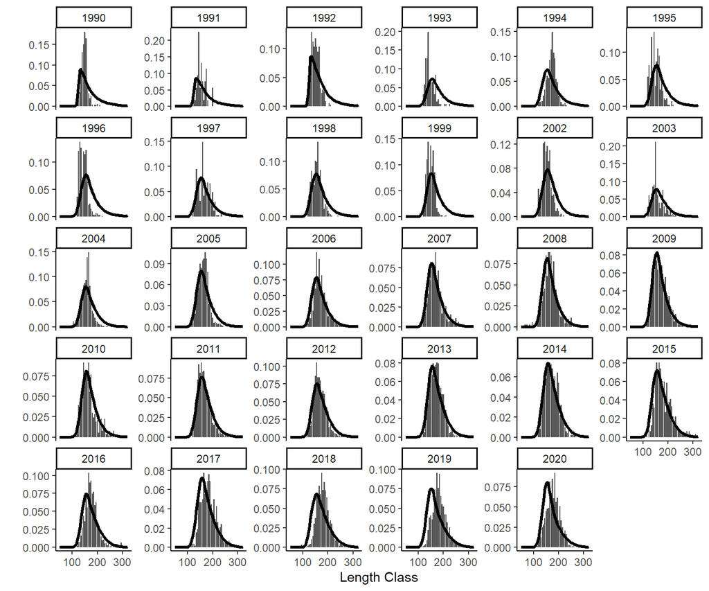

Figure 12. Observed and predicted length composition for Chinese-Taipai LL - Late.

### 6.1.9 Morocco LL

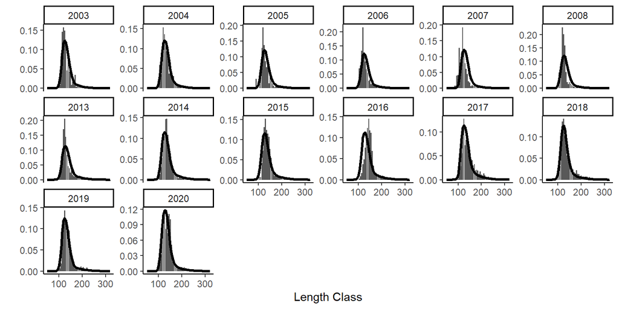

Figure 13. Observed and predicted length composition for Morocco LL.

### 6.1.10 Canada/USA Harpoon

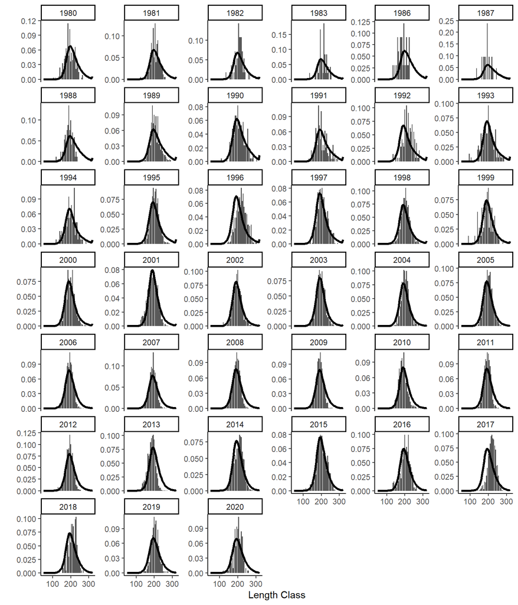

Figure 14. Observed and predicted length composition for Canada/USA Harpoon.

## 6.2 Residual Plots

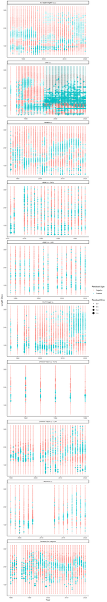

Figure 15. Length composition residuals showing residuals over time for each fleet. Blue circles are positive residuals (observed proportion is higher than expected), red circles are negative residuals. The area of the circle is proportional to the residual error where residual = (observed)^0.5 * (log(observed)-log(predicted)).

## 6.3 Fits to Aggregated Length Composition

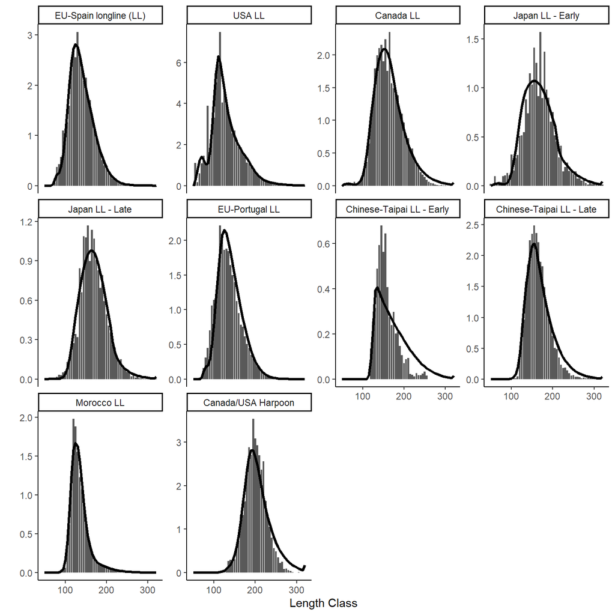

Figure 16. Model predicted length composition (black line) and observed length composition (grey bars) aggregated over all years for each fleet.

# 7 Reference Points

Table 6. The biological reference points calculated for OM: 170.

| MSY (dead) | MSY (retained) | SB<sub>MSY</sub> | F<sub>MSY</sub> | F/F<sub>MSY</sub> | SB/SB<sub>MSY</sub> | SB<sub>MSY</sub>/SB<sub>0</sub> | SB/SB<sub>0</sub> |
| --- | --- | --- | --- | --- | --- | --- | --- |
| 11709.3 | 11086.1 | 33799.9 | 0.12 | 1.71 | 0.52 | 0.25 | 0.13 |

# 8 Kobe Plot

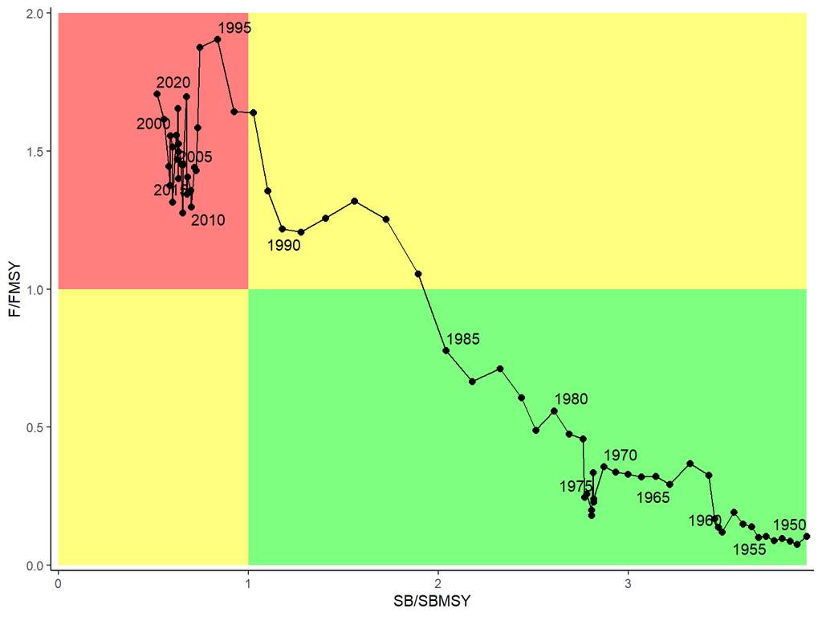

Figure 17. Kobe plot for OM: 170.

# 9 Time-Series Plots of Predicted Stock Dynamics

## 9.1 Spawning Biomass

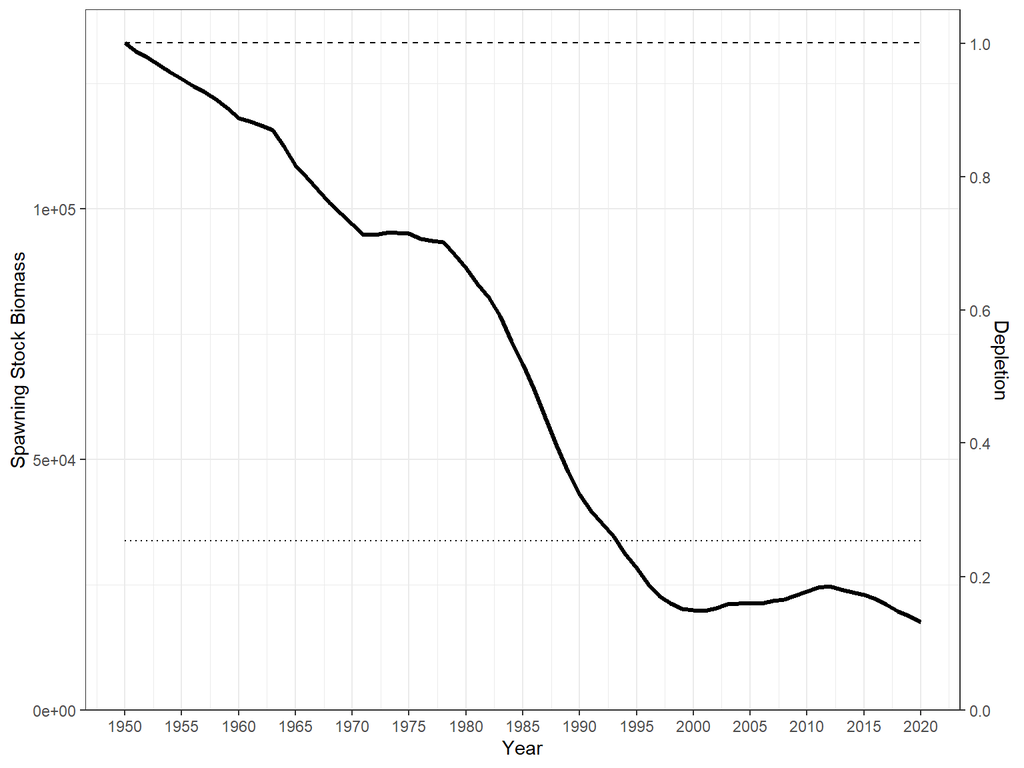

Figure 18. Plot of the predicted historical spawning stock biomass for OM: 170. The dashed black line is the predicted average unfished spawning biomass ($SB_0$). The dotted black line is the equilibrium spawning biomass corresponding with fishing at $F_{MSY}$.

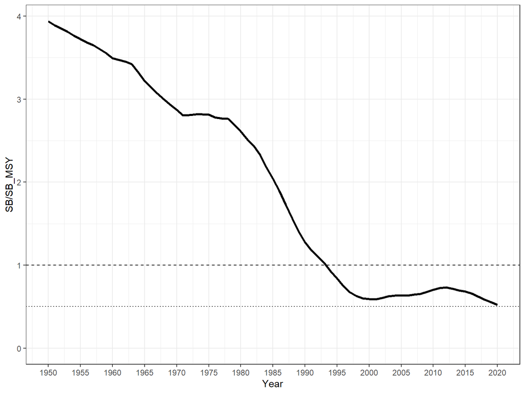

Figure 19. Plot of the predicted historical spawning stock biomass relative to the estimated $SB_\text{MSY}$ for OM: 170.

## 9.2 Recruitment

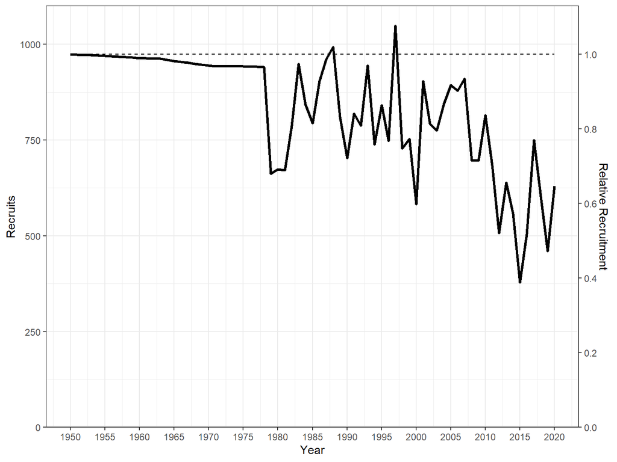

Figure 20. Plot of the predicted historical recruitment for OM: 170. The dashed black line is the estimated average unfished recruitment ($R_0$).

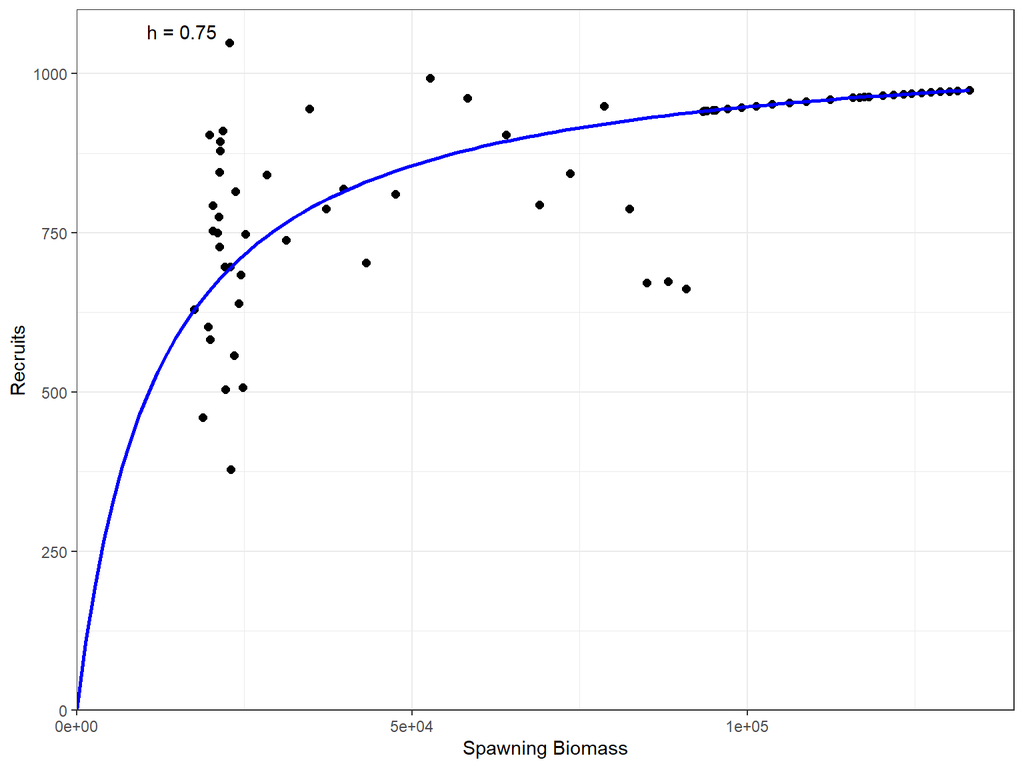

Figure 21. The expected Beverton-Holt stock-recruitment relationship (blue line) and predicted historical recruitment and spawning biomass (black dots).

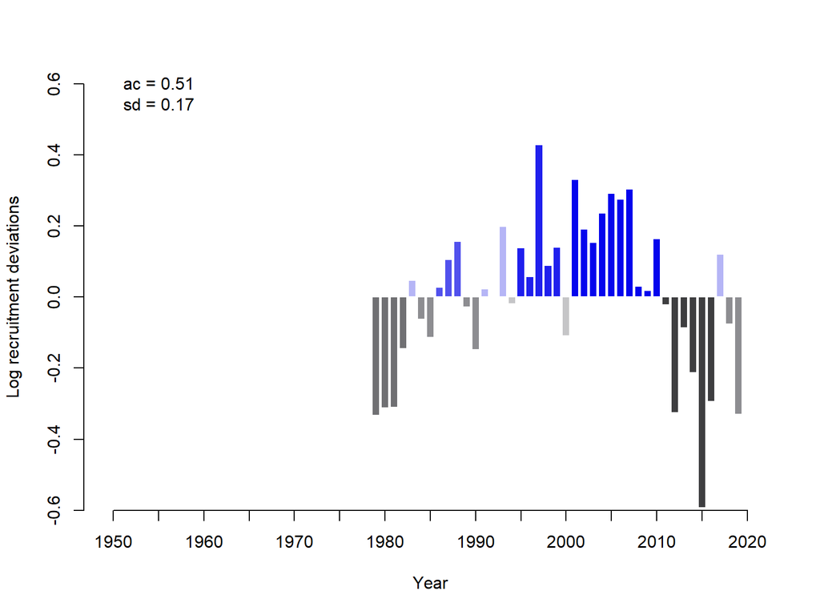

Figure 22. Recruitment deviations (log). Blue bars represent positive deviations where the estimated recruitment is higher than the mean value predicted from the stock-recruitment curve. Grey bars represent negative deviations. ‘ac’. and ‘sd’. refer to the lag-1 autocorrelation and standard deviation in the log recruitment deviations.

# 10 Estimated Selectivity and Retention Curves

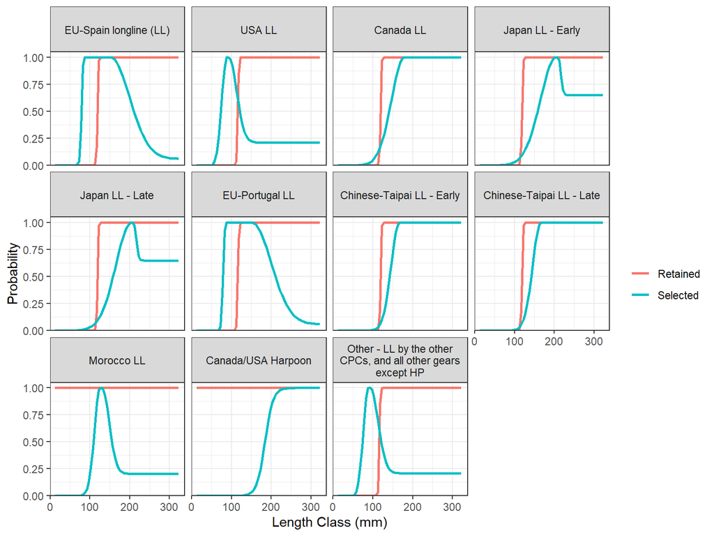

Figure 23. The estimated selectivity- and retention-at-length for the 11 fleets in the terminal year of the assessment (2020).